# Linear Regression Tree Models

Hans W. Borchers Duale Hochschule BW Mannheim

December 2020

## Introduction

The idea of “Linear Regression Trees” is to grow a tree, similar to a decision tree, in which every end node is associated with linear regression for some or all of the variables in the data.

The first idea and implementation was done by Ross Quinlan (of C4.5 fame) in his ‘M5’ program. The following packages contain implementations for building linear regression trees:

- Package ‘Cubist’ with the `cubist()` function  
  (Cubist was the name of the program that Quinlan sold in his RuleQuest company.)
- Package ‘partykit’ provides functions `mob()` and lmtree() for  
  “Model-based recursive partitioning based on least squares regression.”
- `M5P()` (“M5 Prime”) in the RWeka package (part of the Weka software),  
  a reimplementation of the M5 algorithm in Java.

We will use the “Boston Housing” data as an example.

```r
library(mlbench)
data("BostonHousing")
House = BostonHousing[, -14]
value = BostonHousing$medv
```

## Local regression trees

### The ‘Cubist’ package

```r
library(Cubist)
```

The `cubist()` function takes as input a data frame (or matrix) and numerical output. We can decide about the number of ‘committees’ it will apply.

```r
mod1  = cubist(x = House, y = value)
mod10 = cubist(x = House, y = value, committees = 10)
```

The `summary()` shows us the rules of the generated model. We can see the rules of the tree and the regression equations at the nodes.

```r
summary(mod1)
```

```
Call:
cubist.default(x = House, y = value)


Cubist [Release 2.07 GPL Edition]  Thu Jan 14 10:46:47 2021
---------------------------------

    Target attribute `outcome'

Read 506 cases (14 attributes) from undefined.data

Model:

  Rule 1: [101 cases, mean 13.84, range 5 to 27.5, est err 1.98]

    if
    nox > 0.668
    then
    outcome = -1.11 + 2.93 dis + 21.4 nox - 0.33 lstat + 0.008 b
              - 0.13 ptratio - 0.02 crim - 0.003 age + 0.1 rm

  Rule 2: [203 cases, mean 19.42, range 7 to 31, est err 2.10]

    if
    nox <= 0.668
    lstat > 9.59
    then
    outcome = 23.57 + 3.1 rm - 0.81 dis - 0.71 ptratio - 0.048 age
              - 0.15 lstat + 0.01 b - 0.0041 tax - 5.2 nox + 0.05 crim
              + 0.02 rad

  Rule 3: [43 cases, mean 24.00, range 11.9 to 50, est err 2.56]

    if
    rm <= 6.226
    lstat <= 9.59
    then
    outcome = 1.18 + 3.83 crim + 4.3 rm - 0.06 age - 0.11 lstat - 0.003 tax
              - 0.09 dis - 0.08 ptratio

```

[output cut: 20 more lines]

```

       80%   100%    lstat
       60%    92%    nox
       40%   100%    rm
             100%    crim
             100%    age
             100%    dis
             100%    ptratio
              80%    tax
              72%    rad
              60%    b
              32%    zn


Time: 0.0 secs
```

Use “root mean squared error” (RMSE) to compare the two models. Asking for more committees will improve the model significantly,

```r
rmse(value, predict(mod1, House))
```

```
[1] 3.025956
```

```r
rmse(value, predict(mod10, House))
```

```
[1] 2.53904
```

while the plot of actual versus fitted prices does not show such a clear advantage.

```r
par(mar = c(3, 3, 2, 1))
plot(value, predict(mod1, House), col = "black",
     main = "Predicted values for 1 and 10 committees")
points(value, predict(mod10, House), col = "red")
```

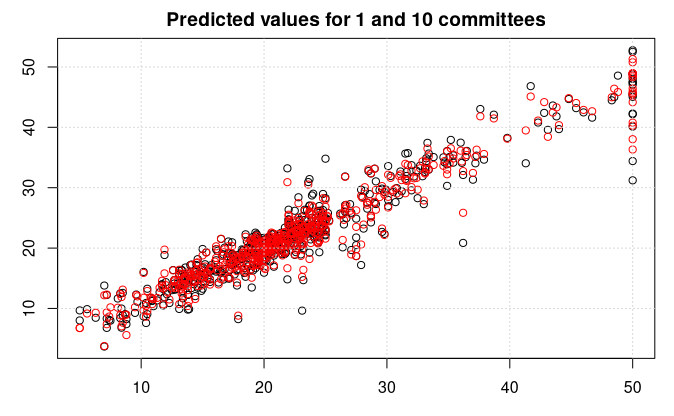

```r
grid()
```

### `lmtree` in package ‘partykit’

’partykit has two functions, `mob()` and `lmtree()`. The algorithmic work is performed by `mob()`, while `lmtree()` simplifies the user call.

```r
library(partykit)
```

The formula for `lmtree()` in general looks like:

```
y ~ z1 + ... + zl or
y ~ x1 + ... + xk | z1 + ... + zl
```

where the `z1, ..., zl` are the variables are used for building the tree, and the `x1, ..., xk` are used in the linear regressions; these two sets can be overlapping.

```r
mod3 = lmtree(medv ~ . | .,data = BostonHousing)
```

That is, we use all variables (except `medv` of course) both for tree splitting and for the linear regression equations.

```r
rmse(value, predict(mod3, House))
```

```
[1] 3.241452
```

[figure not shown]

```r
plot(mod3)
```

## Some comparisons

### Comparison with Random Forest

For a comparison, we will apply a default Random Forest on the data and calculate the RMS error.

```r
library(randomForest)
rf = randomForest(medv ~ ., data = BostonHousing)
rf
```

```
Call:
 randomForest(formula = medv ~ ., data = BostonHousing)
               Type of random forest: regression
                     Number of trees: 500
No. of variables tried at each split: 4

          Mean of squared residuals: 9.881447
                    % Var explained: 88.29
```

```r
rmse(value, predict(rf))
```

```
[1] 3.143477
```

Of course, this is not a reliable accuracy value, it only shows that Quinlan’s M5 in ‘Cubist’ generates an excellent fit.